# Assignment: CNN Classification and Segmentation

Name: Arik Gershman

```python
import os
import sys
import random
import numpy as np
import matplotlib.pyplot as plt
from PIL import Image

import torch
import torch.nn as nn
import torch.nn.functional as F
import torch.optim as optim
import torchvision
import torchvision.transforms as transforms
from torch.utils.data import Dataset, DataLoader

seed = 42
random.seed(seed)
np.random.seed(seed)
torch.manual_seed(seed)

device = torch.device("cuda" if torch.cuda.is_available() else "cpu")
print("Using device:", device)
```

```
Using device: cuda
```

# Part 1: Image Classification with CNN (80 pts, including bonus points)

## Goal

In this part, you will train a convolutional neural network on CIFAR-10.

You will:

1. Load CIFAR-10.
2. Display sample training images.
3. Define a CNN.
4. Train the CNN.
5. Evaluate test accuracy.
6. Compute per-class accuracy and average class accuracy.
7. Plot training loss and test accuracy.

## 1.1 Load CIFAR-10

```python
!pip install datasets -q
```

```python
from datasets import load_dataset

batch_size = 4

transform = transforms.Compose([
    transforms.Resize((32, 32)),
    transforms.ToTensor(),
    transforms.Normalize((0.5, 0.5, 0.5),
                         (0.5, 0.5, 0.5))
])

class HFCIFAR10Dataset(Dataset):
    def __init__(self, split, transform=None):
        self.dataset = load_dataset("uoft-cs/cifar10", split=split)
        self.transform = transform

    def __len__(self):
        return len(self.dataset)

    def __getitem__(self, idx):
        item = self.dataset[idx]
        image = item["img"]
        label = item["label"]

        if self.transform:
            image = self.transform(image)

        return image, label

trainset = HFCIFAR10Dataset("train", transform=transform)
testset = HFCIFAR10Dataset("test", transform=transform)

trainloader = DataLoader(trainset, batch_size=batch_size, shuffle=True, num_workers=2)
testloader = DataLoader(testset, batch_size=batch_size, shuffle=False, num_workers=2)

classes = ("plane", "car", "bird", "cat", "deer",
           "dog", "frog", "horse", "ship", "truck")

print("Training images:", len(trainset))
print("Testing images:", len(testset))
print("Batch size:", batch_size)
```

```
Training images: 50000
Testing images: 10000
Batch size: 4
```

## 1.2 Display Training Images

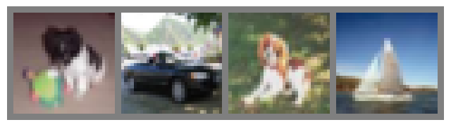

```
Labels: dog car dog ship
```

```python
def imshow(img):
    img = img / 2 + 0.5
    npimg = img.numpy()
    plt.figure(figsize=(8, 4))
    plt.imshow(np.transpose(npimg, (1, 2, 0)))
    plt.axis("off")
    plt.show()

dataiter = iter(trainloader)
images, labels = next(dataiter)

imshow(torchvision.utils.make_grid(images))
print("Labels:", " ".join(classes[labels[j]] for j in range(len(labels))))
```

## 1.3 Define a Simple CNN (20 pts)

The target architecture is:

```
Conv -> ReLU -> MaxPool
Conv -> ReLU -> MaxPool
Flatten
Linear -> ReLU -> Linear
```

This is a lightweight CNN designed to run faster in Colab.

```python
class Net(nn.Module):
    def __init__(self):
        super().__init__()
        """
          Add layers to your neural net.
          Tutorial for reference: https://pytorch.org/tutorials/beginner/introyt/trainingyt.html
        """

        # TODO:
        # Define two convolution layers.
        # The first should take RGB images as input.
        self.conv1 = nn.Conv2d(3, 32, 5)
        self.conv2 = nn.Conv2d(32, 64, 5)

        # TODO:
        # Define a max pooling layer.
        self.pool = nn.MaxPool2d(2, 2)

        # TODO:
        # Define two fully connected layers.
        self.fc1 = nn.Linear(64 * 5 * 5, 256)
        self.fc2 = nn.Linear(256, 128)

        # Define another fully connected layer.
        self.fc3 = nn.Linear(128, 10)

    def forward(self, x):
        """
          Forward pass:
            Apply layers you defined in __init__() to RGB input
            layers: Conv2d --> ReLU --> MaxPool2d --> Conv2d --> ReLU --> MaxPool2d --> Flatten --> Linear --> ReLU --> Linear --> ReLU --> Linear
        """
        # TODO:
        # Apply conv -> relu -> pool twice.
        # Flatten the tensor.
        # Apply two fully connected layers.
        x = self.pool(F.relu(self.conv1(x)))
        x = self.pool(F.relu(self.conv2(x)))
        x = x.view(-1, 64 * 5 * 5)
        x = F.relu(self.fc1(x))
        x = F.relu(self.fc2(x))
        x = self.fc3(x)
        return x

net = Net().to(device)
print(net)
```

```
Net(
  (conv1): Conv2d(3, 32, kernel_size=(5, 5), stride=(1, 1))
  (conv2): Conv2d(32, 64, kernel_size=(5, 5), stride=(1, 1))
  (pool): MaxPool2d(kernel_size=2, stride=2, padding=0, dilation=1, ceil_mode=False)
  (fc1): Linear(in_features=1600, out_features=256, bias=True)
  (fc2): Linear(in_features=256, out_features=128, bias=True)
  (fc3): Linear(in_features=128, out_features=10, bias=True)
)
```

## 1.4 Define Loss and Optimizer (5 pts)

Use cross-entropy loss and Adam optimizer.

The learning rate is fixed at 0.001.

```python
# TODO YOUR CODE HERE: Add loss function (hint: use nn.function_name())
criterion = nn.CrossEntropyLoss()

# TODO YOUR CODE HERE: Add optimizer (hint: use Adam)
optimizer = optim.Adam(net.parameters(), lr=0.001)
```

## 1.5 Train the Network (10 pts)

Train for 5 epochs. During training, record:

- average training loss per epoch
- test accuracy per epoch
- You should at least get 60% accuracy

## Extra Credit (5 pts)

- 5 pts bonus if you get more than 65% accuracy

```python
epochs = 5

train_losses = []
test_accuracies = []

for epoch in range(epochs):
    net.train()
    running_loss = 0.0
    num_batches = 0

    for images, labels in trainloader:
        images = images.to(device)
        labels = labels.to(device)

        # TODO:
        # 1. Clear gradients.
        optimizer.zero_grad()
        # 2. Run forward pass.
        outputs = net(images)
        # 3. Compute loss.
        loss = criterion(outputs, labels)
        # 4. Run backward pass.
        loss.backward()
        # 5. Update weights.
        optimizer.step()

        running_loss += loss.item()
        num_batches += 1

    avg_loss = running_loss / num_batches
    train_losses.append(avg_loss)

    net.eval()
    correct = 0
    total = 0

    with torch.no_grad():
        for images, labels in testloader:
            images = images.to(device)
            labels = labels.to(device)

            # TODO:
            # Run prediction and update correct / total.
            preds = net(images)
            _, predicted = torch.max(preds.data, 1)
            total += labels.size(0)
            correct += (predicted == labels).sum().item()


    test_acc = 100 * correct / total
    test_accuracies.append(test_acc)

    print(f"Epoch {epoch + 1:02d}/{epochs}, Loss: {avg_loss:.4f}, Test Accuracy: {test_acc:.2f}%")
```

[output not shown]

## 1.6 Final Per-Class Accuracy and Average Class Accuracy (10 pts)

Compute accuracy for each CIFAR-10 class.

Then compute average class accuracy:

```
average class accuracy = mean(per-class accuracies)
```

```python
correct_pred = {classname: 0 for classname in classes}
total_pred = {classname: 0 for classname in classes}

net.eval()

with torch.no_grad():
    for images, labels in testloader:
        images = images.to(device)
        labels = labels.to(device)

        # TODO:
        # 1. Compute model outputs.
        outputs = net(images)
        # 2. Convert outputs into predicted labels.
        _, predictions = torch.max(outputs, 1)
        # 3. Update correct_pred and total_pred for each class.
        for label, prediction in zip(labels, predictions):
            label_idx = label.item()
            pred_idx = prediction.item()
            classname = classes[label_idx]
            if label_idx == pred_idx:
                correct_pred[classname] += 1
            total_pred[classname] += 1

class_accuracies = []

for classname in classes:
    accuracy = 100 * correct_pred[classname] / total_pred[classname]
    class_accuracies.append(accuracy)
    print(f"Accuracy for class {classname:5s}: {accuracy:.1f}%")

# TODO:
# Compute average_class_accuracy as the mean of class_accuracies.
average_class_accuracy = sum(class_accuracies) / len(class_accuracies)

print(f"Average class accuracy: {average_class_accuracy:.1f}%")
```

```
Accuracy for class plane: 75.4%
Accuracy for class car  : 77.9%
Accuracy for class bird : 39.7%
Accuracy for class cat  : 31.4%
Accuracy for class deer : 57.9%
Accuracy for class dog  : 50.5%
Accuracy for class frog : 82.6%
Accuracy for class horse: 64.7%
Accuracy for class ship : 74.9%
Accuracy for class truck: 79.7%
Average class accuracy: 63.5%
```

## 1.7 Plots (5 pts)

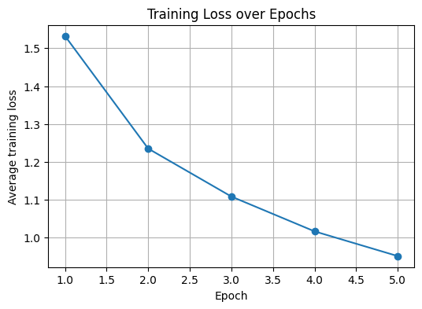

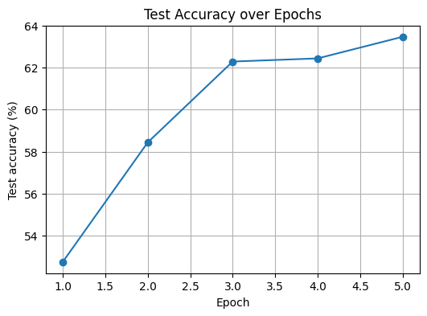

```python
plt.figure(figsize=(6, 4))
plt.plot(range(1, len(train_losses) + 1), train_losses, marker="o")
plt.xlabel("Epoch")
plt.ylabel("Average training loss")
plt.title("Training Loss over Epochs")
plt.grid(True)
plt.show()

plt.figure(figsize=(6, 4))
plt.plot(range(1, len(test_accuracies) + 1), test_accuracies, marker="o")
plt.xlabel("Epoch")
plt.ylabel("Test accuracy (%)")
plt.title("Test Accuracy over Epochs")
plt.grid(True)
plt.show()
```

## Extra Credits (5 pt)

Run VGG with pre-trained weights in this [colab](https://colab.research.google.com/github/pytorch/pytorch.github.io/blob/master/assets/hub/pytorch_vision_vgg.ipynb#scrollTo=daily-wayne). Test any two images of your choice to your model and to VGG model and show accuracy (images must include objects from CIFAR10 classes). Discuss which model performs better and why.

```python
model = torch.hub.load('pytorch/vision:v0.10.0', 'vgg11', pretrained=True)
# or any of these variants
# model = torch.hub.load('pytorch/vision:v0.10.0', 'vgg11_bn', pretrained=True)
# model = torch.hub.load('pytorch/vision:v0.10.0', 'vgg13', pretrained=True)
# model = torch.hub.load('pytorch/vision:v0.10.0', 'vgg13_bn', pretrained=True)
# model = torch.hub.load('pytorch/vision:v0.10.0', 'vgg16', pretrained=True)
# model = torch.hub.load('pytorch/vision:v0.10.0', 'vgg16_bn', pretrained=True)
# model = torch.hub.load('pytorch/vision:v0.10.0', 'vgg19', pretrained=True)
# model = torch.hub.load('pytorch/vision:v0.10.0', 'vgg19_bn', pretrained=True)
model.eval()
net.eval()
model = model.to(device)
```

```
Using cache found in /root/.cache/torch/hub/pytorch_vision_v0.10.0
```

```python
# Download ImageNet labels
!wget https://raw.githubusercontent.com/pytorch/hub/master/imagenet_classes.txt
```

```
--2026-05-31 20:11:39--  https://raw.githubusercontent.com/pytorch/hub/master/imagenet_classes.txt
Resolving raw.githubusercontent.com (raw.githubusercontent.com)... 185.199.108.133, 185.199.109.133, 185.199.110.133, ...
Connecting to raw.githubusercontent.com (raw.githubusercontent.com)|185.199.108.133|:443... connected.
HTTP request sent, awaiting response... 200 OK
Length: 10472 (10K) [text/plain]
Saving to: ‘imagenet_classes.txt.3’

imagenet_classes.tx 100%[===================>]  10.23K  --.-KB/s    in 0s

2026-05-31 20:11:40 (80.6 MB/s) - ‘imagenet_classes.txt.3’ saved [10472/10472]
```

```python
# Read the categories
with open("imagenet_classes.txt", "r") as f:
    categories = [s.strip() for s in f.readlines()]
```

```
Testing image: airplane.jpg
```

[figure not shown]

```
VGG prediction:
airliner 0.9371960759162903
My Model prediction:
plane 0.99993896484375

Testing image: frog.jpg
```

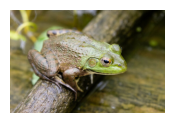

```
VGG prediction:
bullfrog 0.6276424527168274
My Model prediction:
frog 0.6714444756507874

Testing image: bird.jpg
```

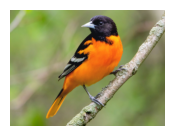

```
VGG prediction:
jacamar 0.24331825971603394
My Model prediction:
bird 0.9863022565841675
```

```python
image_paths = [
    "/content/my_image_1.jpg",
    "/content/my_image_2.png"
]

preprocess = transforms.Compose([
    transforms.Resize(256),
    transforms.CenterCrop(224),
    transforms.ToTensor(),
    transforms.Normalize(mean=[0.485, 0.456, 0.406], std=[0.229, 0.224, 0.225]),
])

indices_to_test = [2, 17]
img_paths = ["airplane.jpg", "frog.jpg", "bird.jpg"]

for img_path in img_paths:
  raw_image = Image.open(img_path).convert('RGB')

  print(f"\nTesting image: {img_path}")

  # Display image for reference
  plt.figure(figsize=(2, 2))
  plt.imshow(raw_image)
  plt.axis("off")
  plt.show()

  # VGG
  input = preprocess(raw_image).unsqueeze(0).to(device)

  if torch.cuda.is_available():
      input = input.to('cuda')
      model.to('cuda')

  with torch.no_grad():
      output = model(input)

  probabilities = torch.nn.functional.softmax(output[0], dim=0)
  top1_prob, top1_catid = torch.topk(probabilities, 1)
  print("VGG prediction:")
  print(categories[top1_catid[0]], top1_prob[0].item())


  # My model
  input = transform(raw_image).unsqueeze(0).to(device)

  if torch.cuda.is_available():
    input = input.to('cuda')
    net.to('cuda')

  with torch.no_grad():
    preds = net(input)
    my_probabilities = torch.nn.functional.softmax(preds[0], dim=0)
    my_top1_prob, my_top1_catid = torch.topk(my_probabilities, 1)

    predicted_class_name = classes[my_top1_catid[0].item()]
    predicted_prob = my_top1_prob[0].item()

    print("My Model prediction:")
    print(f"{predicted_class_name} {predicted_prob}")
```

# Part 2: Image Segmentation with SAM (30 pts)

## Goal

In this part, you will use the Segment Anything Model, SAM, for image segmentation.

You will:

1. Load SAM.
2. Run SAM on a provided example image.
3. Run SAM on two images of your choice.
4. Analyze one failure case.

To make this assignment easier to run, we use the smaller `vit_b` SAM model.

```python
%%capture
!pip install opencv-python matplotlib
!pip install 'git+https://github.com/facebookresearch/segment-anything.git'

!mkdir -p images
!wget -q -P images https://raw.githubusercontent.com/facebookresearch/segment-anything/main/notebooks/images/truck.jpg
!wget -q -P images https://raw.githubusercontent.com/facebookresearch/segment-anything/main/notebooks/images/groceries.jpg

!wget -q https://dl.fbaipublicfiles.com/segment_anything/sam_vit_b_01ec64.pth
```

```python
import cv2
from PIL import Image

def show_mask(mask, ax, random_color=False):
    if random_color:
        color = np.concatenate([np.random.random(3), np.array([0.6])], axis=0)
    else:
        color = np.array([30 / 255, 144 / 255, 255 / 255, 0.6])

    h, w = mask.shape[-2:]
    mask_image = mask.reshape(h, w, 1) * color.reshape(1, 1, -1)
    ax.imshow(mask_image)

def show_points(coords, labels, ax, marker_size=375):
    pos_points = coords[labels == 1]
    neg_points = coords[labels == 0]

    ax.scatter(pos_points[:, 0], pos_points[:, 1],
               color="green", marker="*", s=marker_size,
               edgecolor="white", linewidth=1.25)

    ax.scatter(neg_points[:, 0], neg_points[:, 1],
               color="red", marker="*", s=marker_size,
               edgecolor="white", linewidth=1.25)

def load_rgb_image(path):
    image = cv2.imread(path)
    image = cv2.cvtColor(image, cv2.COLOR_BGR2RGB)
    return image
```

```python
from segment_anything import sam_model_registry, SamPredictor

sam_checkpoint = "sam_vit_b_01ec64.pth"
model_type = "vit_b"

sam = sam_model_registry[model_type](checkpoint=sam_checkpoint)
sam.to(device=device)

predictor = SamPredictor(sam)
print("SAM loaded.")
```

```
SAM loaded.
```

## 2.1 Example: Segment an Object in the Truck Image

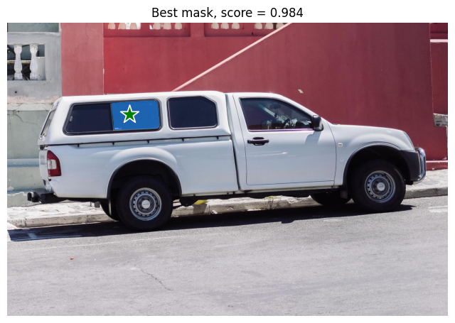

```python
image = load_rgb_image("images/truck.jpg")
predictor.set_image(image)

input_point = np.array([[500, 375]])
input_label = np.array([1])

masks, scores, logits = predictor.predict(
    point_coords=input_point,
    point_labels=input_label,
    multimask_output=True,
)

best_mask_index = np.argmax(scores)

plt.figure(figsize=(8, 8))
plt.imshow(image)
show_mask(masks[best_mask_index], plt.gca())
show_points(input_point, input_label, plt.gca())
plt.title(f"Best mask, score = {scores[best_mask_index]:.3f}")
plt.axis("off")
plt.show()
```

## 2.2 Your Own Images (10 pts)

Run SAM on two images of your choice.

For each image:

1. Display the original image.
2. Choose one foreground point.
3. Display one segmentation mask.
4. Briefly explain whether the mask is good or bad.

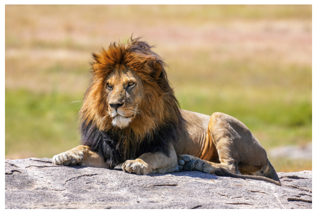

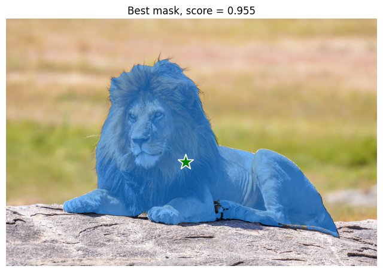

[figure not shown]

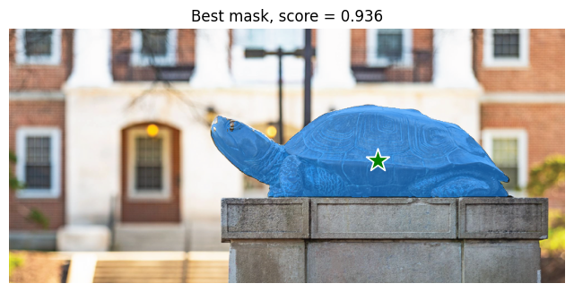

```python
# TODO:
# Replace the image paths and input points below with your own choices.
# You may upload images to Colab and use their file paths.

image_path_1 = "lion.jpg"
input_point_1 = np.array([[2500, 2000]])

image_path_2 = "testudo.jpg"
input_point_2 = np.array([[530, 190]])

for path, point in [(image_path_1, input_point_1), (image_path_2, input_point_2)]:
    image = load_rgb_image(path)
    predictor.set_image(image)

    # Show original image
    plt.figure(figsize=(8, 8))
    plt.axis("off")
    plt.imshow(image)

    input_point = point
    input_label = np.array([1])

    # TODO:
    # Run predictor.predict.
    masks, scores, logits = predictor.predict(
      point_coords=input_point,
      point_labels=input_label,
      multimask_output=True,
    )
    # Select one mask.
    best_mask_index = np.argmax(scores)
    # Display the image with the selected mask and point.
    plt.figure(figsize=(8, 8))
    plt.imshow(image)
    show_mask(masks[best_mask_index], plt.gca())
    show_points(input_point, input_label, plt.gca())
    plt.title(f"Best mask, score = {scores[best_mask_index]:.3f}")
    plt.axis("off")
    plt.show()
```

## 2.3 Failure Case (5 pts)

Find one case where SAM does not segment the object well.

Examples:

- The mask includes too much background.
- The mask misses part of the object.
- The object is very small.
- The object is occluded.
- The scene has many overlapping objects.

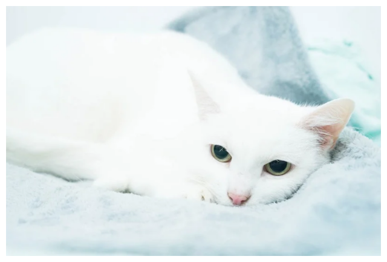

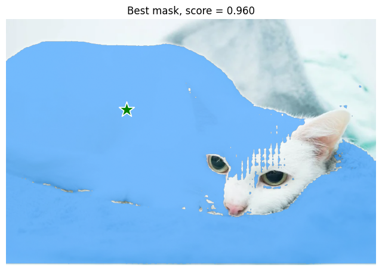

[output not shown]

```python
# TODO:
# Run SAM on one failure case.
# Display the image, selected point, and mask.
# Then explain why the result may have failed.

image = load_rgb_image("cat.jpg")
predictor.set_image(image)

# Show original image
plt.figure(figsize=(8, 8))
plt.axis("off")
plt.imshow(image)

input_point = np.array([[400, 300]])
input_label = np.array([1])

masks, scores, logits = predictor.predict(
    point_coords=input_point,
    point_labels=input_label,
    multimask_output=True,
)

best_mask_index = np.argmax(scores)

plt.figure(figsize=(8, 8))
plt.imshow(image)
show_mask(masks[best_mask_index], plt.gca())
show_points(input_point, input_label, plt.gca())
plt.title(f"Best mask, score = {scores[best_mask_index]:.3f}")
plt.axis("off")
plt.show()


"""
The above cat picture is a case where SAM fails successfully segment the object.
The human eye slightly struggles to see the full bounds of the cat, but it is
still pretty clear. SAM misses some parts of the cat and includes parts of the
blanket. I believe the reason this result has failed is because the foreground
and background of the image are both white, and it is difficult for SAM to
distinguish between them. I also think it did not segment the cat's eyes
because they seem like they are a part of a different object due to their
contrast with the rest of the cat's body.
"""
```

## Part 2 Write-up (15 pts)

Answer the following questions.

1. What types of images or objects does SAM segment well? SAM sucessfully segments objects that have clear outlines, which are objects that have a strong contrast between the foreground and the background. Also, images that have distinct and no overlapping objects. Some examples of such images include the lion and Testudo images I used above.
2. What types of images or objects are difficult for SAM? SAM struggles with the opposite. It struggles with images/objects that do not have strong contrast between the foreground and the background. Meaning, images where it is unclear where an object's edge/outline is. It also struggles with images that have overlapping or obscured objects. The above cat image is an example of an image SAM struggles with.
3. How does changing the input point affect the result? Changing the input point changes SAM's focus within the image, segmenting different objects. For example, if there are 2 distinct objects in an image, placing the input point on one of them will have SAM create the best mask for that object, whereas placing it on the other one will segment the other one.

# Grading Rubric

Accuracy guidance for Part 1:

- Below 45%: likely implementation or training issue
- 45% to 55%: acceptable for this small model and short training setting
- 55% to 60%: good result
- Above 60%: strong result for this lightweight CNN

# Save as PDF

```python
!apt-get update
!dpkg --configure -a
!apt-get install -y texlive texlive-xetex texlive-latex-extra pandoc
!pip install pypandoc
```

[output not shown]

[output cut: 338 more lines]

[output not shown]

```python
from google.colab import drive
drive.mount('/content/drive')
```

```python
!cp /content/drive/MyDrive/CMSC426/CMSC426_Assignment5_sp26.ipynb ./
!jupyter nbconvert --to HTML "CMSC426_Assignment5_sp26.ipynb"
```